# Task2. Data Analysis

Simone Lu, Marco Pisano, Lorenzo Antolini

13/12/2021

#Data visualizations with Ggplot2, we runned the libraries necessary to retrieve the data from a URL and for plotting the graphs.

```r
library (readr)
library(ggplot2)
```

#we imported from our colleagues repository of github.

```r
urlfile="https://raw.githubusercontent.com/Enricograndi/MeM_project_work/main/Data/binance_data.csv"
mydata <- read_csv(url(urlfile))
```

```
## * `` -> ...1
```

```r
View(mydata)
```

#1)plot the distrubution of the number of trades, it is not normal distributed.

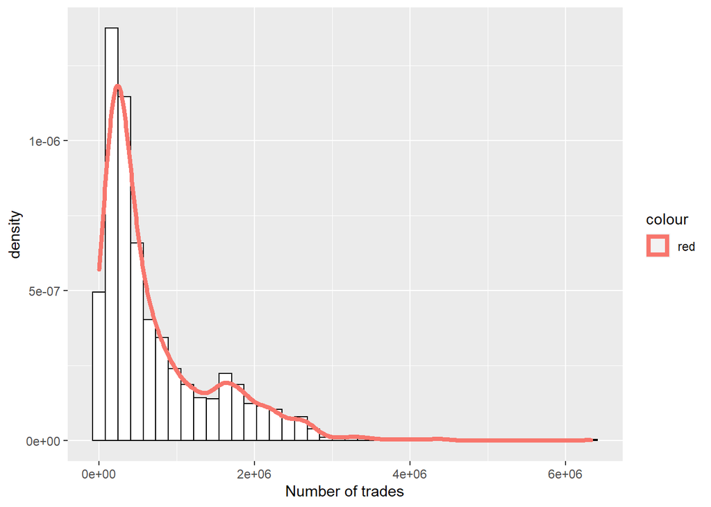

```r
a <- ggplot(mydata, aes(x = `Number of trades`, y= ..density.., color = "red")) +
  geom_histogram(bins = 40, color = "black",
                 fill = "white")
a <-  a + geom_density(kernel= "gaussian", size= 1.5)
a
```

#2)second plot is the boxplot of all the variables in the dataset by excluding the non numerical variables.before doing it that, we normalized the data and we boxplot all the variables.

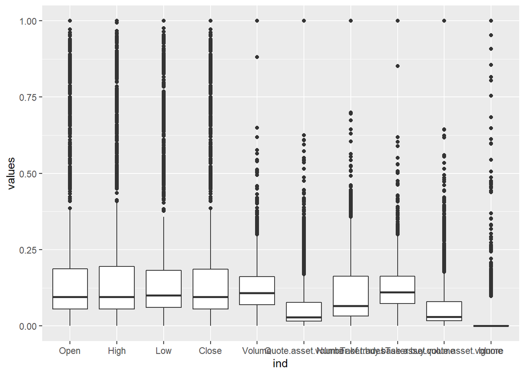

```r
min_max_norm <- function(x) {
  (x - min(x)) / (max(x) - min(x))
}

data_norm <- as.data.frame(lapply(mydata[c(3,4,5,6,7,9,10,11,12,13)], min_max_norm))

#with ggplot
ggplot(stack(data_norm), aes(x=ind, y =values))+
  geom_boxplot()
```

#3)time series graph in order to see the price changes from 2018 to 2021

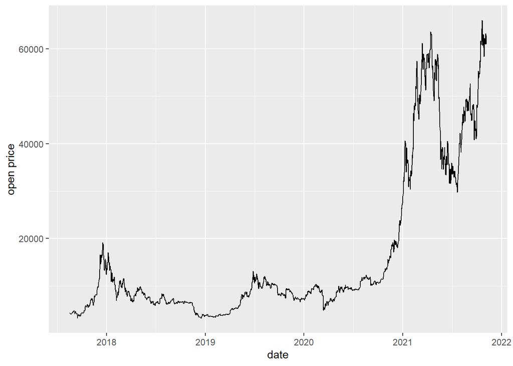

```r
ggplot(data = mydata, aes(mydata$`Open time`, y = Open)) +
  geom_line() +
  labs(x = "date", y = "open price")
```

#4)time series with number of transactions.

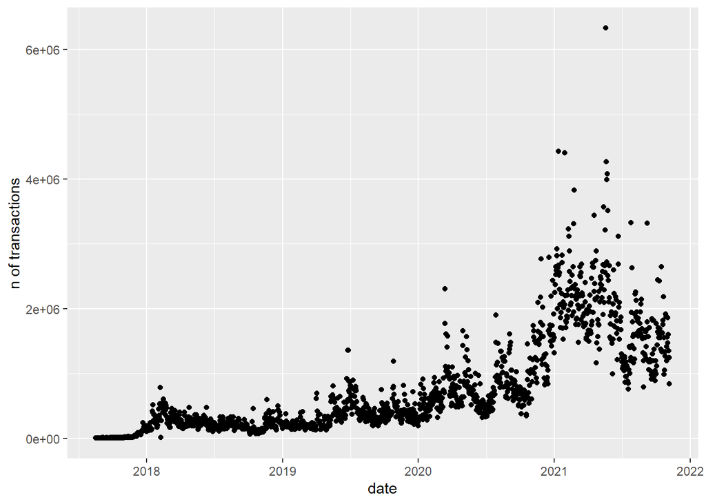

```r
ggplot(data = mydata, aes(mydata$`Open time`, mydata$`Number of trades`)) +
  geom_point() +
  labs(x = "date", y = "n of transactions")
```

#Data manipulation

```r
library(tidyverse)
library(magrittr)
```

#i inspect the data to see the number of observations and the variable’s types

```r
str(mydata)
```

```
## spec_tbl_df [1,543 x 13] (S3: spec_tbl_df/tbl_df/tbl/data.frame)
##  $ ...1                        : num [1:1543] 0 1 2 3 4 5 6 7 8 9 ...
##  $ Open time                   : Date[1:1543], format: "2017-08-17" "2017-08-18" ...
##  $ Open                        : num [1:1543] 4261 4285 4108 4121 4069 ...
##  $ High                        : num [1:1543] 4485 4372 4185 4211 4120 ...
##  $ Low                         : num [1:1543] 4201 3939 3850 4033 3912 ...
##  $ Close                       : num [1:1543] 4285 4108 4140 4086 4016 ...
##  $ Volume                      : num [1:1543] 795 1200 381 467 692 ...
##  $ Close time                  : POSIXct[1:1543], format: "2017-08-17 23:59:59" "2017-08-18 23:59:59" ...
##  $ Quote asset volume          : num [1:1543] 3454770 5086958 1549484 1930364 2797232 ...
##  $ Number of trades            : num [1:1543] 3427 5233 2153 2321 3972 ...
##  $ Taker buy base asset volume : num [1:1543] 616 973 274 377 557 ...
##  $ Taker buy quote asset volume: num [1:1543] 2678216 4129123 1118002 1557401 2255663 ...
##  $ Ignore                      : num [1:1543] 8734 9384 9184 10125 11707 ...
##  - attr(*, "spec")=
##   .. cols(
##   ..   ...1 = col_double(),
##   ..   `Open time` = col_date(format = ""),
##   ..   Open = col_double(),
##   ..   High = col_double(),
##   ..   Low = col_double(),
##   ..   Close = col_double(),
##   ..   Volume = col_double(),
##   ..   `Close time` = col_datetime(format = ""),
##   ..   `Quote asset volume` = col_double(),
##   ..   `Number of trades` = col_double(),
##   ..   `Taker buy base asset volume` = col_double(),
##   ..   `Taker buy quote asset volume` = col_double(),
##   ..   Ignore = col_double()
##   .. )
##  - attr(*, "problems")=<externalptr>
```

#firstly, i removed all the not available values

```r
na.omit(mydata)
```

```
## # A tibble: 1,543 x 13
##     ...1 `Open time`  Open  High   Low Close Volume `Close time`
##    <dbl> <date>      <dbl> <dbl> <dbl> <dbl>  <dbl> <dttm>
##  1     0 2017-08-17  4261. 4485. 4201. 4285.   795. 2017-08-17 23:59:59
##  2     1 2017-08-18  4285. 4372. 3939. 4108.  1200. 2017-08-18 23:59:59
##  3     2 2017-08-19  4108. 4185. 3850  4140.   381. 2017-08-19 23:59:59
##  4     3 2017-08-20  4121. 4211. 4033. 4086.   467. 2017-08-20 23:59:59
##  5     4 2017-08-21  4069. 4120. 3912. 4016    692. 2017-08-21 23:59:59
##  6     5 2017-08-22  4016  4105. 3400  4040    967. 2017-08-22 23:59:59
##  7     6 2017-08-23  4040  4266. 4014. 4114.  1001. 2017-08-23 23:59:59
##  8     7 2017-08-24  4147  4372. 4085. 4316.   787. 2017-08-24 23:59:59
##  9     8 2017-08-25  4316. 4454. 4247. 4281.   574. 2017-08-25 23:59:59
## 10     9 2017-08-26  4281. 4367  4212. 4337.   228. 2017-08-26 23:59:59
## # ... with 1,533 more rows, and 5 more variables: Quote asset volume <dbl>,
## #   Number of trades <dbl>, Taker buy base asset volume <dbl>,
## #   Taker buy quote asset volume <dbl>, Ignore <dbl>
```

#with command “select”,we take some specific colums

```r
mydata%>%
select(`Open time`,Open,Close,Volume)
```

```
## # A tibble: 1,543 x 4
##    `Open time`  Open Close Volume
##    <date>      <dbl> <dbl>  <dbl>
##  1 2017-08-17  4261. 4285.   795.
##  2 2017-08-18  4285. 4108.  1200.
##  3 2017-08-19  4108. 4140.   381.
##  4 2017-08-20  4121. 4086.   467.
##  5 2017-08-21  4069. 4016    692.
##  6 2017-08-22  4016  4040    967.
##  7 2017-08-23  4040  4114.  1001.
##  8 2017-08-24  4147  4316.   787.
##  9 2017-08-25  4316. 4281.   574.
## 10 2017-08-26  4281. 4337.   228.
## # ... with 1,533 more rows
```

# if we want to see all the observations that has volume higher than the mean, we can

#use the command “filter”

```r
vol_mean <- mean(mydata$Volume)
vol_above_the_mean <- filter(mydata, Volume > vol_mean)
vol_above_the_mean$Volume
```

```
##   [1]  63401.17  72331.80  63403.18 100201.50  60778.46  52427.60  61137.38
##   [8]  68113.82  67060.17  57202.70  64112.29  52291.02  59488.23  55297.08
##  [15]  54620.92  65306.03  64861.60  55044.52  81110.04  52342.02  52157.37
##  [22]  52105.42  59487.64  60121.16  59550.54  51941.19  59034.97  53895.83
##  [29]  68806.69  57851.61  53742.32  77909.39  63715.26  60644.46  51779.34
##  [36]  90748.03  70580.89 117380.95  61071.83  61693.11 101693.98  94503.75
##  [43]  67480.61  91983.57  73980.20  67758.45  68378.80  95145.46  55365.95
##  [50]  66761.75  61369.62  94137.34 101543.84  82343.85  64647.81  62725.63
##  [57]  59402.23  64042.73  62224.19 105383.64 109890.13  61054.25  54696.60
##  [64]  74022.42  86948.98  85804.74  76583.72  69630.51  88752.01  65577.44
##  [71]  65859.21  52301.75  51886.77  70380.00  74143.95  63289.25  51554.57
##  [78] 104169.45  57445.32  61276.69 155930.15 173894.82  95795.20  69642.07
##  [85]  84512.53  90962.27 109561.04  96815.90  66512.22  63534.35  51469.50
##  [92]  52182.37  78442.13 109246.04  87506.46  56321.86  54245.59  72517.58
##  [99]  81922.43  97219.44  84942.67  80283.31  56546.93  65153.67  76705.39
```

[output cut: 71 more lines]

#another, if we want work only on the stock price in 2018

```r
mydata%>%
filter(mydata$`Open time`>= as.Date("2018-01-01") & mydata$`Open time` <= ("2018-12-31"))
```

```
## # A tibble: 365 x 13
##     ...1 `Open time`   Open   High    Low  Close Volume `Close time`
##    <dbl> <date>       <dbl>  <dbl>  <dbl>  <dbl>  <dbl> <dttm>
##  1   137 2018-01-01  13716. 13819. 12750  13380   8610. 2018-01-01 23:59:59
##  2   138 2018-01-02  13382. 15473. 12890. 14675. 20078. 2018-01-02 23:59:59
##  3   139 2018-01-03  14690  15308. 14150  14920. 15906. 2018-01-03 23:59:59
##  4   140 2018-01-04  14920. 15280  13918. 15060. 21330. 2018-01-04 23:59:59
##  5   141 2018-01-05  15060. 17176. 14600  16960. 23251. 2018-01-05 23:59:59
##  6   142 2018-01-06  16960. 17143. 16011. 17070. 18571. 2018-01-06 23:59:59
##  7   143 2018-01-07  17070. 17100. 15610  16150. 12493. 2018-01-07 23:59:59
##  8   144 2018-01-08  16219. 16322. 12812  14903. 26601. 2018-01-08 23:59:59
##  9   145 2018-01-09  14903. 15500  14011. 14400  14315. 2018-01-09 23:59:59
## 10   146 2018-01-10  14401  14956. 13131. 14907. 17411. 2018-01-10 23:59:59
## # ... with 355 more rows, and 5 more variables: Quote asset volume <dbl>,
## #   Number of trades <dbl>, Taker buy base asset volume <dbl>,
## #   Taker buy quote asset volume <dbl>, Ignore <dbl>
```

#select only numeric columns

```r
mydata2 = select_if(mydata, is.numeric)
```

#we calculate the mean of the close price

```r
mydata%>%
summarise(mean = mean(Close), n = n())
```

```
## # A tibble: 1 x 2
##     mean     n
##    <dbl> <int>
## 1 16120.  1543
```